# Exploring vital rate models

Kelley Erickson

May 16, 2019

# 0. Setup

### Load the data

```r
#Load demographic data
demog<-read.csv("demography_15_clean.csv", head=T)
library(AICcmodavg)
library(fields)
library(viridis)
my.palette <- viridis(9)
```

This is a csv file where each row is a an individual.

The column names are :

- `Obs` : Observation number (each plant should have a different observation number; these were assigned post data entry when we discovered that some of the numbers for individuals were reused between sites
- `Site`: Which site (Big Cypress, Cape Canaveral, Chekika, Forty Pierce, Punta Gorda, Wild Turkey)
- `Plant ID`: The tag number of an individual (each individual in a site has a different number, but numbers were reused across sites)
- `Location`: SeedlingPlot (individual located in a seedling plot) or NA (individual not in seedling plot)
- `Date_i`: The date the census took place for censuses i = 1:7
- `Status_i`: One of four categories for censuses i=1:7:
  - **alive**: individual was alive when censused
  - **firstdead**: the individual was recorded as dead at this census and was alive at the last census
  - **missing**: the individual was not located at this census
  - **prestudy**: the individual had not been tagged yet
  - **stilldead**: the individual was already marked dead at a previous census
- `Death_Cause_i`: One of three categories for censuses i = 1:7:
  - **NA**: for individuals that died, there was no reason to suspect their deaths were due to management actions
  - **sprayed**: individual death attributed to being sprayed with herbicide (these individuals should be excluded)
  - **fire**: individual death attributed to fire (these individuals should be excluded from analysis)
- `Rep_stat_i`: One of 4 categories for censuses i = 1:7:
  - **NA**: for individuals whose reproductive status is unknown at census i
  - **female**: for individuals who have produced fruit at any previous census up to an including census i
  - **male**: for individuals who have not produced fruit at any previous census (may have observed male flowers)
  - **pre-reproductive**: for individuals who have not produced fruit at any previous census
- `Diam_i`: Diameter (in mm) of individual at census i
- `Height_i`: Height (in cm) of individual at census i
- `Max_i`: Maximum canopy width in cm of individual at census i
- `Min_i`: Minimum canopy width in cm of individual at census i
- `Multistem`: For each individual takes on one of two values:
  - **NA**: individuals that are not multistem
  - **FLAG**: Individuals that are multistem

## Stack data

```r
#### Restructure the data in a few different ways:


Dates <- c(rep(2009, 1512), rep(2010, 1512), rep(2011, 1512), rep(2012, 1512), rep(2013, 1512), rep(2014, 1512))



Death_Cause<-c(demog$Death_Cause_2, demog$Death_Cause_3, demog$Death_Cause_4, demog$Death_Cause_5, demog$Death_Cause_6, demog$Death_Cause_7)

Status<-c(demog$Status_1, demog$Status_2, demog$Status_3, demog$Status_4, demog$Status_5, demog$Status_6, demog$Status_7)

Diams<-cbind(demog$Diam_1, demog$Diam_2, demog$Diam_3, demog$Diam_4, demog$Diam_5, demog$Diam_6, demog$Diam_7)

row.names(Diams)<-demog$Plant_ID

Heights<-cbind(demog$Height_1, demog$Height_2, demog$Height_3, demog$Height_4, demog$Height_5, demog$Height_6, demog$Height_7)

row.names(Heights)<-demog$Plant_ID

Mins<-cbind(demog$Min_1, demog$Min_2, demog$Min_3, demog$Min_4, demog$Min_5, demog$Min_6, demog$Min_7)

row.names(Mins)<-demog$Plant_ID

Maxs<-cbind(demog$Max_1, demog$Max_2, demog$Max_3, demog$Max_4, demog$Max_5, demog$Max_6, demog$Max_7)

row.names(Maxs)<-demog$Plant_ID

Diams_pooled<-rbind( cbind(Diams[,1], Diams[,2]), cbind(Diams[,2], Diams[,3]), cbind(Diams[, 3], Diams[,4]), cbind(Diams[,4], Diams[,5]), cbind(Diams[,5], Diams[,6]), cbind(Diams[, 6], Diams[, 7]))

Diams_pooled<-data.frame(Diams_pooled[,1], Diams_pooled[,2])

names(Diams_pooled)<-c("t", "t_plus_one")

Sites_pooled<-rep(demog$Site, 6)

ID_pooled<-rep(demog$Plant_ID, 6)

Location<-rep(demog$Location, 6)

Genetic_type_pooled<-rep(0, length(Sites_pooled))

#code which sites are which biotype
for (i in 1:length(Genetic_type_pooled)) {
    if (Sites_pooled[i]=="Big Cypress") Genetic_type_pooled[i]<-"hybrid"
    else if (Sites_pooled[i]=="Cape Canaveral") Genetic_type_pooled[i]<-"hybrid"
    else if (Sites_pooled[i]=="Chekika") Genetic_type_pooled[i]<-"eastern"
    else if (Sites_pooled[i]=="Fort Pierce") Genetic_type_pooled[i]<-"eastern"
    else if (Sites_pooled[i]=="Punta Gorda") Genetic_type_pooled[i]<-"western"
    else Genetic_type_pooled[i]<-"western"

}



Heights_pooled<-rbind( cbind(Heights[,1], Heights[,2]), cbind(Heights[,2], Heights[,3]), cbind(Heights[, 3], Heights[,4]), cbind(Heights[,4], Heights[,5]), cbind(Heights[,5], Heights[,6]), cbind(Heights[, 6], Heights[, 7]))

Heights_pooled<-data.frame(Heights_pooled[,1], Heights_pooled[,2])
names(Heights_pooled)<-c("t", "t_plus_one")



#Finish for maxs and mins

Maxs_pooled<-rbind(cbind(Maxs[,1], Maxs[,2]), cbind(Maxs[,2], Maxs[,3]),
    cbind(Maxs[,3], Maxs[,4]), cbind(Maxs[,4], Maxs[,5]),
    cbind(Maxs[,5], Maxs[,6]), cbind(Maxs[,6], Maxs[,7]))

Maxs_pooled<-data.frame(Maxs_pooled[,1], Maxs_pooled[,2])
names(Maxs_pooled)<-c("t", "t_plus_one")



Mins_pooled<-rbind( cbind(Mins[,1], Mins[,2]), cbind(Mins[,2], Mins[,3]),
    cbind(Mins[,3], Mins[,4]), cbind(Mins[,4], Mins[,5]),
    cbind(Mins[, 5], Mins[,6]), cbind(Mins[,6], Mins[,7]))

Mins_pooled<-data.frame(Mins_pooled[,1], Mins_pooled[,2])
names(Mins_pooled)<-c("t", "t_plus_one")




###Use status matrix to get survival matrix
statmat<-as.matrix(demog[, c(6, 14, 22, 30, 38, 46, 54)])
survmat<-statmat
survmat<- ifelse(survmat=="prestudy"|survmat=="missing"|survmat=="still_dead", NA, survmat)
survmat<- ifelse(survmat =="tagged"|survmat=="alive", 1, 0)

survmat_pooled<-rbind( cbind(survmat[,1], survmat[,2]), cbind(survmat[,2], survmat[,3]), cbind(survmat[, 3], survmat[,4]), cbind(survmat[,4], survmat[,5]), cbind(survmat[,5], survmat[,6]), cbind(survmat[, 6], survmat[, 7]))
names(survmat_pooled)<-c("surv_t", "surv_t_plus_one")


survmat_pooled_bysize<-cbind(Diams_pooled[, 1], survmat_pooled[,2])
names(survmat_pooled_bysize)<-c("size_t", "surv_t_plus_one")



#Use reproduction status matrix to get reproduction matrix
repstatmat<-as.matrix(demog[, c(8, 16, 24, 32, 40, 48, 56)])
repmat<-repstatmat
repmat<- ifelse(repmat =="female", 1, 0)
repmat_pooled<-rbind( cbind(repmat[,1], repmat[,2]), cbind(repmat[,2], repmat[,3]), cbind(repmat[, 3], repmat[,4]), cbind(repmat[,4], repmat[,5]), cbind(repmat[,5], repmat[,6]), cbind(repmat[, 6], repmat[, 7]))


pooled<-cbind(ID_pooled, Sites_pooled, Location, Death_Cause, Genetic_type_pooled, Mins_pooled, Maxs_pooled, Diams_pooled, Heights_pooled, repmat_pooled, survmat_pooled, Dates)
names(pooled)<-c("ID", "Site","Location", "Death_Cause", "Genetic_type", "Min_t", "Min_tplus1", "Max_t", "Max_tplus1", "Diameter_t", "Diameter_tplus1", "Height_t", "Height_tplus1", "Rep_t", "Rep_tplus1", "Surv_t", "Surv_tplus1", "Year")
```

## Investigate relationships among possible state variables

```r
predictors<-cbind(pooled$Min_t, pooled$Diameter_t, pooled$Height_t, pooled$Max_t)

# What is the correlation amongst the predictor variables?
correlation<-cor(predictors[, 1:4], use="pairwise.complete.obs")
colnames(correlation)<-c("Min", "Diameter", "Height", "Max")
rownames(correlation)<-c("Min", "Diameter", "Height", "Max")

correlation<-round(correlation, 2)
print(correlation)
```

```
##           Min Diameter Height  Max
## Min      1.00     0.70   0.85 0.94
## Diameter 0.70     1.00   0.58 0.68
## Height   0.85     0.58   1.00 0.87
## Max      0.94     0.68   0.87 1.00
```

```r
#Over the entire dataset, there is the lowest correlation between diameter and height
```

## Exclude outliers

```r
#Remove individual deaths that were sprayed or fire or grinding
restrict<-subset(pooled, is.na(Death_Cause))

#Remove outliers (very large diameters)
restrict2<-subset(restrict, Diameter_t<800)

#Questioning why we did this? does this lead to model-eviction?
#Range of diameter: [0, 800]
0.9*max(restrict2$Diameter_t) #700
```

```
## [1] 625.5
```

```r
#Range of height:  [0, 800]
0.9*max(restrict2$Height_t, na.rm=T) #800
```

```
## [1] 729
```

## Divide dataset into size domains (seedlings and larges)

```r
seedlings<-subset(restrict2, restrict2$Diameter_t<1.6)
seedlings<-subset(seedlings, seedlings$Height_t<16)
larges<-subset(restrict2, restrict2$Diameter_t>1.6)
larges<-subset(larges, larges$Height_t>16)

x1seq_larges<-seq(1.6, 800, length.out=50)
x2seq_larges<-seq(16, 800, length.out=50)

x1seq_seedlings<-seq(0, 1.6, length.out=50)
x2seq_seedlings<-seq(0, 16, length.out=50)

grad_status<-rep(NA, length(seedlings$ID))
for (i in 1:length(seedlings$ID)) {
  if (is.na(seedlings$Diameter_tplus1[i])) {
    grad_status[i]<-NA
  }
  else if (is.na(seedlings$Height_tplus1[i])) {
    grad_status[i]<-NA
  }
  else if (seedlings$Diameter_tplus1[i]>1.6& seedlings$Height_tplus1[i]>16) { grad_status[i]<-1}
  else {grad_status[i]<-0}
}

seedlings<-cbind(seedlings, grad_status)
```

# Exploratory Statistics

There are 1512 individuals

| Big Cypress | Cape Canaveral | Chekika | Fort Pierce | Punta Gorda | Wild Turkey |
| --- | --- | --- | --- | --- | --- |
| 308 | 226 | 460 | 166 | 175 | 177 |

| Eastern | Hybrid | Western |
| --- | --- | --- |
| 626 | 534 | 352 |

```r
summary(seedlings$Site)
```

```
##    Big Cypress Cape Canaveral        Chekika    Fort Pierce    Punta Gorda
##            211            165            389             76             58
##    Wild Turkey
##             60
```

```r
summary(seedlings$Genetic_type)
```

```
## eastern  hybrid western
##     465     376     118
```

```r
summary(as.factor(seedlings$Year))
```

```
## 2009 2010 2011 2012 2013 2014
##  120  195   59  351  165   69
```

```r
summary(larges$Site)
```

```
##    Big Cypress Cape Canaveral        Chekika    Fort Pierce    Punta Gorda
##            682            483            546            542            422
##    Wild Turkey
##            477
```

```r
summary(larges$Genetic_type)
```

```
## eastern  hybrid western
##    1088    1165     899
```

```r
summary(as.factor(larges$Year))
```

```
## 2009 2010 2011 2012 2013 2014
##  299  631  645  572  518  487
```

The number of deaths (0) by biotype:

```r
table(seedlings$Surv_tplus1, seedlings$Genetic_type)
```

```
##
##     eastern hybrid western
##   0     304    165      67
##   1     146    170      43
```

```r
table(larges$Surv_tplus1, larges$Genetic_type)
```

```
##
##     eastern hybrid western
##   0      82     34      66
##   1     983    922     822
```

The number of deaths(0) by site:

```r
table(seedlings$Surv_tplus1, seedlings$Site)
```

```
##
##     Big Cypress Cape Canaveral Chekika Fort Pierce Punta Gorda Wild Turkey
##   0         119             46     277          27          31          36
##   1          73             97     104          42          20          23
```

```r
table(larges$Surv_tplus1, larges$Site)
```

```
##
##     Big Cypress Cape Canaveral Chekika Fort Pierce Punta Gorda Wild Turkey
##   0          20             14      51          31          20          46
##   1         550            372     478         505         397         425
```

```r
table(seedlings$Surv_tplus1, seedlings$Year)
```

```
##
##     2009 2010 2011 2012 2013 2014
##   0   24   81   36  264  120   11
##   1   96  105   23   86   45    4
```

```r
table(larges$Surv_tplus1, larges$Year)
```

```
##
##     2009 2010 2011 2012 2013 2014
##   0    0   31   51   50   28   22
##   1  299  595  582  517  489  245
```

# Define some plotting variables:

```r
x1seq_seedlings<-seq(0, 1.6, length.out=50)

x2seq_seedlings<-seq(0, 16, length.out=50)
x1seq_larges <- seq(0, 800, length.out = 50 )
x2seq_larges <- seq (0, 800, length.out = 50)

invlogit<-function(x){exp(x)/(1+exp(x))}

# Function to do an image plot of a matrix in the usual orientation, A(1,1) at top left
matrix.image=function(x,y,A,col=topo.colors(200),...) {
    nx=length(x); ny=length(y);
    x1=c(1.5*x[1]-0.5*x[2],1.5*x[nx]-0.5*x[nx-1]);
    y1=c(1.5*y[1]-0.5*y[2],1.5*y[ny]-0.5*y[ny-1]);
    image.plot(list(x=x,y=y,z=t(A)),xlim=x1,ylim=rev(y1),col=col,bty="u",...);
}
```

# 1. Maturation models

Choosing which state variables to use and whether to include terms for biotype, site or year (for the year effect, only including data from years where all sites were sampled, so AIC cannot be compared with other models)

- Diameter-only models:
  - m1: logit(m) = b0 + b1(diameter)
  - m2: logit(m) = b0 + b1(diameter) + epsilon(biotype{E,H,W})
  - m3: logit(m) = b0 + b1(diameter) + epsilon(site{BC, CC, C, FP, PG, WT})
  - m4: logit(m) = b0 + b1(diameter) + epsilon(year{2010, 2011, 2012, 2013, 2014}
- Height-only models
  - m5: logit(m) = b0 + b1(height)
  - m6: logit(m) = b0 + b1(height) + epsilon(biotype{E,H,W})
  - m7: logit(m) = b0 + b1(height) + epsilon(site{BC, CC, C, FP, PG, WT})
  - m8: logit(m) = b0 + b1(height) + epsilon(year{2010, 2011, 2012, 2013, 2014}
- Diameter + Height models
  - m9: logit(m) = b0 + b1(diameter) + b2(height)
  - m10: logit(m) = b0 + b1(diameter) + b2(height) + epsilon(biotype{E,H,W})
  - m11: logit(m) = b0 + b1(diameter) + b2(height) + epsilon(site{BC, CC, C, FP, PG,WT})
  - m12: loigt(m) = b0 + b1(diameter) + b2(height) + epsilon(year{2010, 2011, 2012, 2013, 2014})

### – m1: logit(m) = b0 + b1(diameter) —–

```r
  m1 <- glm(seedlings$grad_status ~ seedlings$Diameter_t, family = binomial)
  summary(m1)
```

```
##
## Call:
## glm(formula = seedlings$grad_status ~ seedlings$Diameter_t, family = binomial)
##
## Deviance Residuals:
##     Min       1Q   Median       3Q      Max
## -0.9608  -0.4426  -0.3745  -0.2667   2.4577
##
## Coefficients:
##                      Estimate Std. Error z value Pr(>|z|)
## (Intercept)           -5.7550     0.8445  -6.815 9.42e-12 ***
## seedlings$Diameter_t   3.4811     0.7406   4.700 2.60e-06 ***
## ---
## Signif. codes:  0 '***' 0.001 '**' 0.01 '*' 0.05 '.' 0.1 ' ' 1
##
## (Dispersion parameter for binomial family taken to be 1)
##
##     Null deviance: 236.89  on 352  degrees of freedom
## Residual deviance: 212.59  on 351  degrees of freedom
##   (606 observations deleted due to missingness)
## AIC: 216.59
##
## Number of Fisher Scoring iterations: 5
```

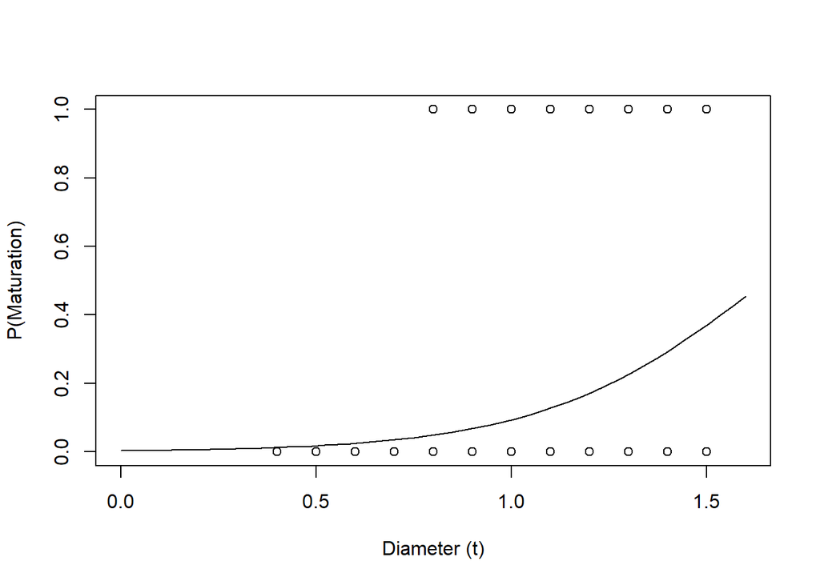

```r
plot(x1seq_seedlings, invlogit(m1$coeff[1] + m1$coeff[2]*x1seq_seedlings), type='l', ylim=c(0,1) , xlab = "Diameter (t)", ylab="P(Maturation)")
points(seedlings$Diameter_t, seedlings$grad_status)
```

### –m2: logit(m) = b0 + b1(diameter) + epsilon(biotype{E,H,W})

Hybrid is not significantly different from Eastern

```r
  m2 <- glm(seedlings$grad_status ~ seedlings$Diameter_t + seedlings$Genetic_type, family = binomial)
summary(m2)
```

```
##
## Call:
## glm(formula = seedlings$grad_status ~ seedlings$Diameter_t +
##     seedlings$Genetic_type, family = binomial)
##
## Deviance Residuals:
##     Min       1Q   Median       3Q      Max
## -1.3657  -0.4460  -0.3260  -0.2267   2.5917
##
## Coefficients:
##                               Estimate Std. Error z value Pr(>|z|)
## (Intercept)                    -6.2504     0.9083  -6.881 5.93e-12 ***
## seedlings$Diameter_t            3.2525     0.7661   4.245 2.18e-05 ***
## seedlings$Genetic_typehybrid    0.7401     0.4957   1.493  0.13539
## seedlings$Genetic_typewestern   1.8041     0.5657   3.189  0.00143 **
## ---
## Signif. codes:  0 '***' 0.001 '**' 0.01 '*' 0.05 '.' 0.1 ' ' 1
##
## (Dispersion parameter for binomial family taken to be 1)
##
##     Null deviance: 236.89  on 352  degrees of freedom
## Residual deviance: 201.98  on 349  degrees of freedom
##   (606 observations deleted due to missingness)
## AIC: 209.98
##
## Number of Fisher Scoring iterations: 6
```

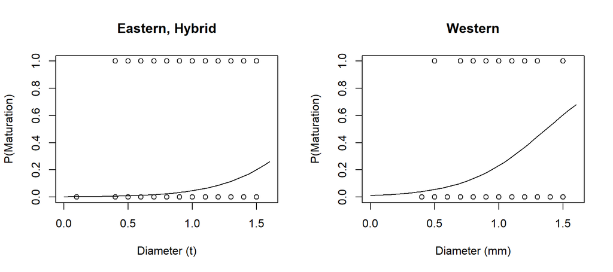

```r
par(mfrow=c(1, 2))

plot(x1seq_seedlings, invlogit(m2$coeff[1] + m2$coeff[2]*x1seq_seedlings), type='l', ylim=c(0,1) , xlab = "Diameter (t)", ylab="P(Maturation)", main = "Eastern, Hybrid")
points(seedlings[seedlings$Genetic_type=="eastern" | seedlings$Genetic_type == "hybrid", ]$Diameter_t, seedlings[seedlings$Genetic_type=="eastern" | seedlings$Genetic_type == "hybrid", ]$Surv_tplus1)

plot(x1seq_seedlings, invlogit(m2$coeff[1] + m2$coeff[2]*x1seq_seedlings + m2$coeff[4]), type='l', ylim=c(0,1) , xlab = "Diameter (mm)", ylab="P(Maturation)", main = "Western")
points(seedlings[seedlings$Genetic_type=="western", ]$Diameter_t, seedlings[seedlings$Genetic_type=="western", ]$Surv_tplus1)
```

### –m3: logit(m) = b0 + b1(diameter) + epsilon(biotype{BC, CC, C, FP, PG, WT})

Big Cypress, Cape Canaveral, Fort Pierce and Punta Gorda are not different

```r
  m3 <- glm(seedlings$grad_status ~ seedlings$Diameter_t + seedlings$Site, family =
              binomial)
  summary(m3)
```

```
##
## Call:
## glm(formula = seedlings$grad_status ~ seedlings$Diameter_t +
##     seedlings$Site, family = binomial)
##
## Deviance Residuals:
##     Min       1Q   Median       3Q      Max
## -1.5499  -0.4199  -0.2706  -0.1081   2.5790
##
## Coefficients:
##                              Estimate Std. Error z value Pr(>|z|)
## (Intercept)                   -6.1368     1.0175  -6.031 1.63e-09 ***
## seedlings$Diameter_t           4.2706     0.8632   4.947 7.52e-07 ***
## seedlings$SiteCape Canaveral  -0.9956     0.5206  -1.913  0.05580 .
## seedlings$SiteChekika         -2.8463     1.0736  -2.651  0.00802 **
## seedlings$SiteFort Pierce      0.3364     0.6284   0.535  0.59243
## seedlings$SitePunta Gorda     -0.6153     0.7850  -0.784  0.43317
## seedlings$SiteWild Turkey      1.4284     0.6056   2.359  0.01834 *
## ---
## Signif. codes:  0 '***' 0.001 '**' 0.01 '*' 0.05 '.' 0.1 ' ' 1
##
## (Dispersion parameter for binomial family taken to be 1)
##
##     Null deviance: 236.89  on 352  degrees of freedom
## Residual deviance: 181.88  on 346  degrees of freedom
##   (606 observations deleted due to missingness)
## AIC: 195.88
##
## Number of Fisher Scoring iterations: 7
```

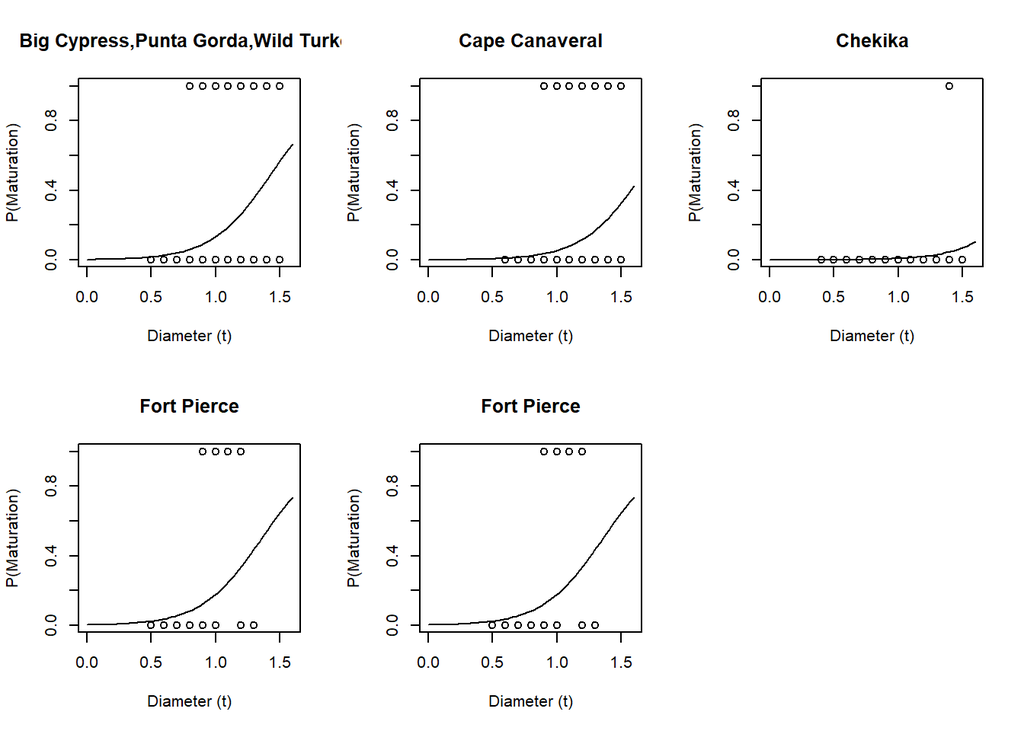

```r
  par(mfrow=c(2, 3))

plot(x1seq_seedlings, invlogit(m3$coeff[1] + m3$coeff[2]*x1seq_seedlings), type='l', ylim=c(0,1) , xlab = "Diameter (t)", ylab="P(Maturation)", main = "Big Cypress,Punta Gorda,Wild Turkey")
points(seedlings[seedlings$Site=="Big Cypress" | seedlings$Site == "Punta Gorda" | seedlings$Site == "Wild Turkey", ]$Diameter_t, seedlings[seedlings$Site=="Big Cypress" | seedlings$Site == "Punta Gorda" | seedlings$Site == "Wild Turkey", ]$grad_status)

plot(x1seq_seedlings, invlogit(m3$coeff[1] + m3$coeff[2]*x1seq_seedlings + m3$coeff[3]), type='l', ylim=c(0,1) , xlab = "Diameter (t)", ylab="P(Maturation)", main = "Cape Canaveral")
points(seedlings[seedlings$Site=="Cape Canaveral", ]$Diameter_t, seedlings[seedlings$Site=="Cape Canaveral", ]$grad_status)

plot(x1seq_seedlings, invlogit(m3$coeff[1] + m3$coeff[2]*x1seq_seedlings + m3$coeff[4]), type='l', ylim=c(0,1) , xlab = "Diameter (t)", ylab="P(Maturation)", main = "Chekika")
points(seedlings[seedlings$Site=="Chekika", ]$Diameter_t, seedlings[seedlings$Site=="Chekika", ]$grad_status)

plot(x1seq_seedlings, invlogit(m3$coeff[1] + m3$coeff[2]*x1seq_seedlings + m3$coeff[5]), type='l', ylim=c(0,1) , xlab = "Diameter (t)", ylab="P(Maturation)", main = "Fort Pierce")
points(seedlings[seedlings$Site=="Fort Pierce", ]$Diameter_t, seedlings[seedlings$Site=="Fort Pierce", ]$grad_status)

plot(x1seq_seedlings, invlogit(m3$coeff[1] + m3$coeff[2]*x1seq_seedlings + m3$coeff[5]), type='l', ylim=c(0,1) , xlab = "Diameter (t)", ylab="P(Maturation)", main = "Fort Pierce")
points(seedlings[seedlings$Site=="Fort Pierce", ]$Diameter_t, seedlings[seedlings$Site=="Fort Pierce", ]$grad_status)
```

### –m4: logit(m) = b0 + b1(diameter) + epsilon(year{2010, 2011, 2012, 2013}

```r
seedlings2 <- subset(seedlings, seedlings$Year > 2009 & seedlings$Year <2014)
seedlings2$Year <- as.factor(seedlings2$Year)
m4 <- glm(seedlings2$grad_status ~ seedlings2$Diameter_t + seedlings2$Year, family = binomial)
summary(m4)
```

```
##
## Call:
## glm(formula = seedlings2$grad_status ~ seedlings2$Diameter_t +
##     seedlings2$Year, family = binomial)
##
## Deviance Residuals:
##     Min       1Q   Median       3Q      Max
## -1.3320  -0.5494  -0.2151  -0.1553   2.8699
##
## Coefficients:
##                       Estimate Std. Error z value Pr(>|z|)
## (Intercept)            -4.2955     1.0295  -4.172 3.02e-05 ***
## seedlings2$Diameter_t   3.1012     0.9198   3.372 0.000747 ***
## seedlings2$Year2011    -1.4959     0.7019  -2.131 0.033082 *
## seedlings2$Year2012    -2.5606     0.7586  -3.375 0.000737 ***
## seedlings2$Year2013    -2.9076     1.0472  -2.776 0.005496 **
## ---
## Signif. codes:  0 '***' 0.001 '**' 0.01 '*' 0.05 '.' 0.1 ' ' 1
##
## (Dispersion parameter for binomial family taken to be 1)
##
##     Null deviance: 199.69  on 252  degrees of freedom
## Residual deviance: 155.45  on 248  degrees of freedom
##   (517 observations deleted due to missingness)
## AIC: 165.45
##
## Number of Fisher Scoring iterations: 6
```

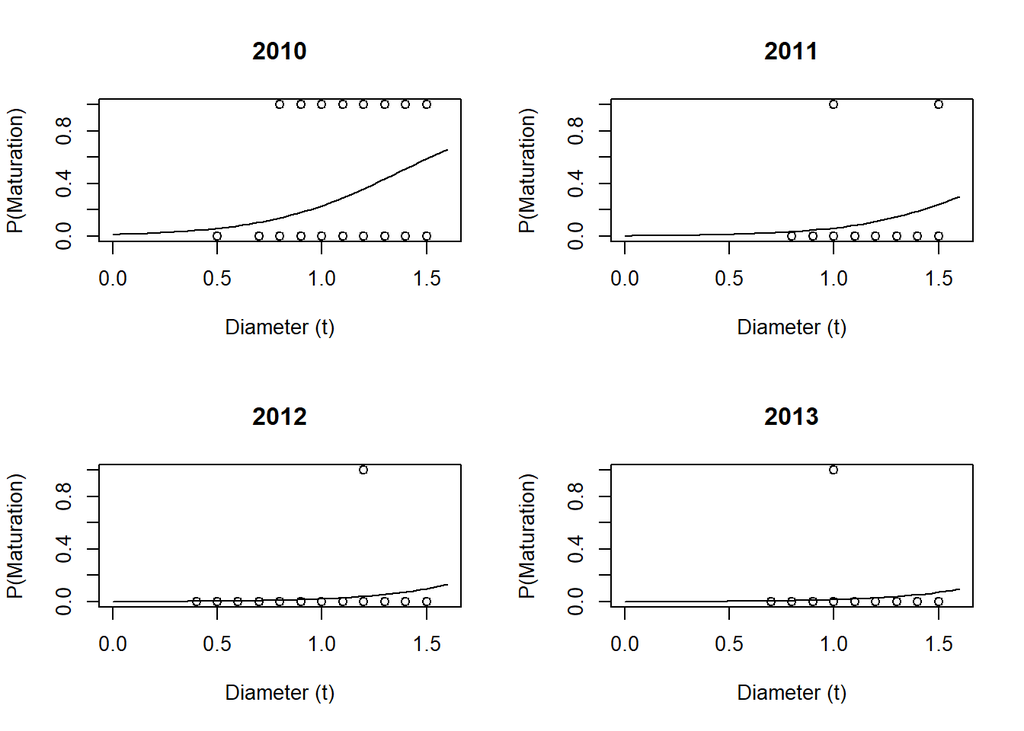

```r
par(mfrow=c(2,2))
plot(x1seq_seedlings, invlogit(m4$coeff[1] + m4$coeff[2]*x1seq_seedlings ), type='l', ylim=c(0,1) , xlab = "Diameter (t)", ylab="P(Maturation)", main = "2010")
points(seedlings2[seedlings2$Year=="2010", ]$Diameter_t, seedlings2[seedlings2$Year=="2010", ]$grad_status)
plot(x1seq_seedlings, invlogit(m4$coeff[1] + m4$coeff[2]*x1seq_seedlings + m4$coeff[3] ), type='l', ylim=c(0,1) , xlab = "Diameter (t)", ylab="P(Maturation)", main = "2011")
points(seedlings2[seedlings2$Year=="2011", ]$Diameter_t, seedlings2[seedlings2$Year=="2011", ]$grad_status)
plot(x1seq_seedlings, invlogit(m4$coeff[1] + m4$coeff[2]*x1seq_seedlings + m4$coeff[4] ), type='l', ylim=c(0,1) , xlab = "Diameter (t)", ylab="P(Maturation)", main = "2012")
points(seedlings2[seedlings2$Year=="2012", ]$Diameter_t, seedlings2[seedlings2$Year=="2012", ]$grad_status)

plot(x1seq_seedlings, invlogit(m4$coeff[1] + m4$coeff[2]*x1seq_seedlings + m4$coeff[5] ), type='l', ylim=c(0,1) , xlab = "Diameter (t)", ylab="P(Maturation)", main = "2013")
points(seedlings2[seedlings2$Year=="2013", ]$Diameter_t, seedlings2[seedlings2$Year=="2013", ]$grad_status)
```

### –m5: logit(m) = b0 + b1(height)

```r
  m5 <- glm(seedlings$grad_status ~ seedlings$Height_t, family = binomial)
  summary(m5)
```

```
##
## Call:
## glm(formula = seedlings$grad_status ~ seedlings$Height_t, family = binomial)
##
## Deviance Residuals:
##     Min       1Q   Median       3Q      Max
## -0.8689  -0.5122  -0.3864  -0.2896   2.6374
##
## Coefficients:
##                    Estimate Std. Error z value Pr(>|z|)
## (Intercept)        -5.22488    0.78388  -6.665 2.64e-11 ***
## seedlings$Height_t  0.29636    0.06792   4.363 1.28e-05 ***
## ---
## Signif. codes:  0 '***' 0.001 '**' 0.01 '*' 0.05 '.' 0.1 ' ' 1
##
## (Dispersion parameter for binomial family taken to be 1)
##
##     Null deviance: 236.89  on 352  degrees of freedom
## Residual deviance: 215.32  on 351  degrees of freedom
##   (606 observations deleted due to missingness)
## AIC: 219.32
##
## Number of Fisher Scoring iterations: 5
```

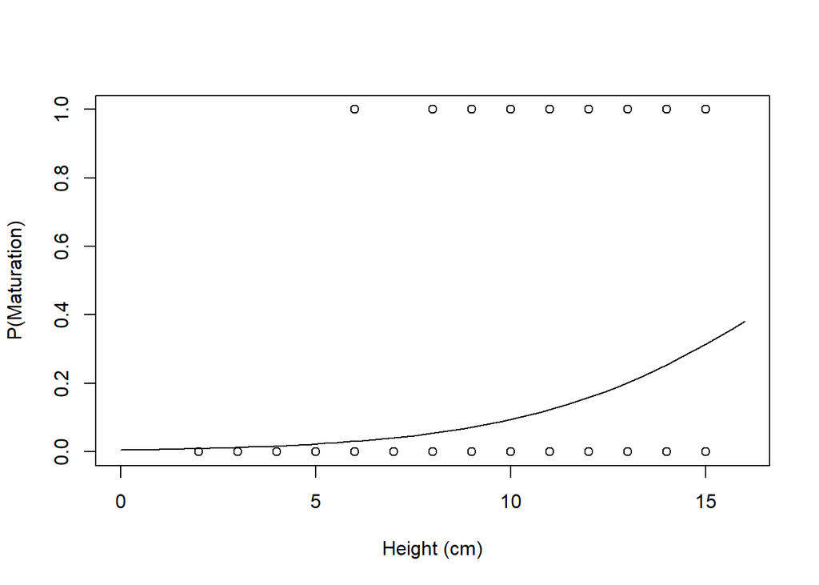

```r
plot(x2seq_seedlings, invlogit(m5$coeff[1] + m5$coeff[2]*x2seq_seedlings), type='l', ylim=c(0,1) , xlab = "Height (cm)", ylab="P(Maturation)")
points(seedlings$Height_t, seedlings$grad_status)
```

### –m6: logit(m) = b0 + b1(height) + epsilon(biotype{E,H,W})

```r
 m6 <- glm(seedlings$grad_status ~ seedlings$Height_t + seedlings$Genetic_type, family = binomial)
summary(m6)
```

```
##
## Call:
## glm(formula = seedlings$grad_status ~ seedlings$Height_t + seedlings$Genetic_type,
##     family = binomial)
##
## Deviance Residuals:
##     Min       1Q   Median       3Q      Max
## -1.2468  -0.4817  -0.3189  -0.2128   2.7566
##
## Coefficients:
##                               Estimate Std. Error z value Pr(>|z|)
## (Intercept)                   -6.06506    0.89185  -6.801 1.04e-11 ***
## seedlings$Height_t             0.28604    0.06941   4.121 3.77e-05 ***
## seedlings$Genetic_typehybrid   1.10921    0.49035   2.262 0.023692 *
## seedlings$Genetic_typewestern  1.93615    0.56406   3.433 0.000598 ***
## ---
## Signif. codes:  0 '***' 0.001 '**' 0.01 '*' 0.05 '.' 0.1 ' ' 1
##
## (Dispersion parameter for binomial family taken to be 1)
##
##     Null deviance: 236.89  on 352  degrees of freedom
## Residual deviance: 202.20  on 349  degrees of freedom
##   (606 observations deleted due to missingness)
## AIC: 210.2
##
## Number of Fisher Scoring iterations: 6
```

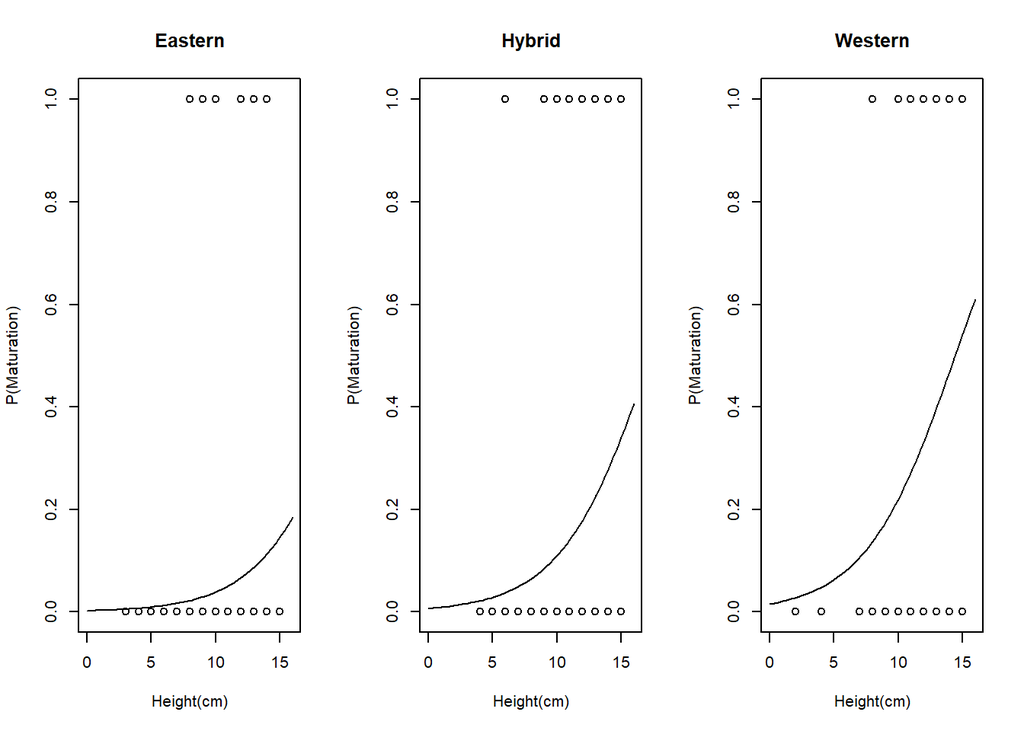

```r
par(mfrow=c(1, 3))

plot(x2seq_seedlings, invlogit(m6$coeff[1] + m6$coeff[2]*x2seq_seedlings), type='l', ylim=c(0,1) , xlab = "Height(cm)", ylab="P(Maturation)", main = "Eastern")
points(seedlings[seedlings$Genetic_type=="eastern", ]$Height_t, seedlings[seedlings$Genetic_type=="eastern", ]$grad_status)

plot(x2seq_seedlings, invlogit(m6$coeff[1] + m6$coeff[2]*x2seq_seedlings + m6$coeff[3]), type='l', ylim=c(0,1) , xlab = "Height(cm)", ylab="P(Maturation)", main = "Hybrid")
points(seedlings[seedlings$Genetic_type=="hybrid", ]$Height_t, seedlings[seedlings$Genetic_type=="hybrid", ]$grad_status)

plot(x2seq_seedlings, invlogit(m6$coeff[1] + m6$coeff[2]*x2seq_seedlings + m6$coeff[4]), type='l', ylim=c(0,1) , xlab = "Height(cm)", ylab="P(Maturation)", main = "Western")
points(seedlings[seedlings$Genetic_type=="western", ]$Height_t, seedlings[seedlings$Genetic_type=="western", ]$grad_status)
```

### –m7: logit(m) = b0 + b1(height) + epsilon(site{BC, CC, C, FP, PG, WT}) Big Cypress, Cape Canaveral, Fort Pierce and Punta Gorda are not different

```r
  m7 <- glm(seedlings$grad_status ~ seedlings$Height_t + seedlings$Site, family = binomial)
  summary(m7)
```

```
##
## Call:
## glm(formula = seedlings$grad_status ~ seedlings$Height_t + seedlings$Site,
##     family = binomial)
##
## Deviance Residuals:
##     Min       1Q   Median       3Q      Max
## -1.4331  -0.4844  -0.3067  -0.1255   2.9061
##
## Coefficients:
##                              Estimate Std. Error z value Pr(>|z|)
## (Intercept)                  -5.33234    0.98003  -5.441 5.30e-08 ***
## seedlings$Height_t            0.31641    0.07689   4.115 3.87e-05 ***
## seedlings$SiteCape Canaveral  0.08445    0.51412   0.164   0.8695
## seedlings$SiteChekika        -2.67243    1.06538  -2.508   0.0121 *
## seedlings$SiteFort Pierce     0.31897    0.61377   0.520   0.6033
## seedlings$SitePunta Gorda     0.32025    0.75508   0.424   0.6715
## seedlings$SiteWild Turkey     1.16976    0.57872   2.021   0.0433 *
## ---
## Signif. codes:  0 '***' 0.001 '**' 0.01 '*' 0.05 '.' 0.1 ' ' 1
##
## (Dispersion parameter for binomial family taken to be 1)
##
##     Null deviance: 236.89  on 352  degrees of freedom
## Residual deviance: 190.94  on 346  degrees of freedom
##   (606 observations deleted due to missingness)
## AIC: 204.94
##
## Number of Fisher Scoring iterations: 7
```

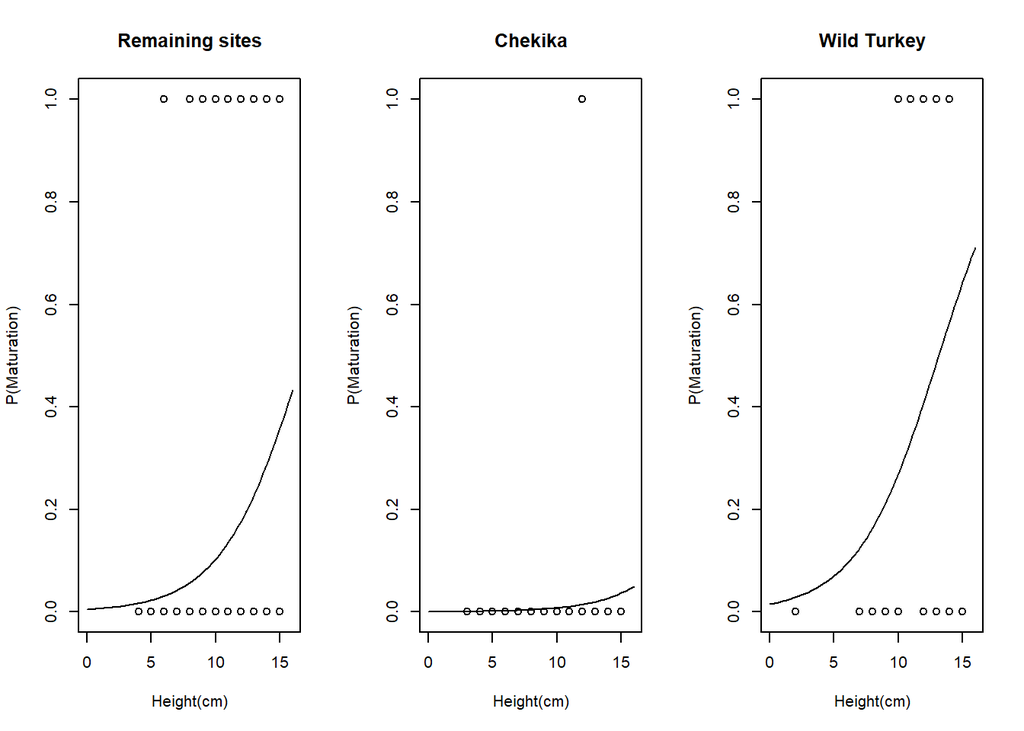

```r
  par(mfrow=c(1,3))
  plot(x2seq_seedlings, invlogit(m7$coeff[1] + m7$coeff[2]*x2seq_seedlings), type='l', ylim=c(0,1) , xlab = "Height(cm)", ylab="P(Maturation)", main = "Remaining sites")
points(seedlings[seedlings$Site!="Chekika" & seedlings$Site!= "Wild Turkey", ]$Height_t, seedlings[seedlings$Site!="Chekika" & seedlings$Site != "Wild Turkey", ]$grad_status)

 plot(x2seq_seedlings, invlogit(m7$coeff[1] + m7$coeff[2]*x2seq_seedlings + m7$coeff[4]), type='l', ylim=c(0,1) , xlab = "Height(cm)", ylab="P(Maturation)", main = "Chekika")
points(seedlings[seedlings$Site== "Chekika", ]$Height_t, seedlings[seedlings$Site=="Chekika", ]$grad_status)

 plot(x2seq_seedlings, invlogit(m7$coeff[1] + m7$coeff[2]*x2seq_seedlings + m7$coeff[7]), type='l', ylim=c(0,1) , xlab = "Height(cm)", ylab="P(Maturation)", main = "Wild Turkey")
points(seedlings[seedlings$Site== "Wild Turkey", ]$Height_t, seedlings[seedlings$Site=="Wild Turkey", ]$grad_status)
```

### –m8: logit(m) = b0 + b1(height) + epsilon(year{2010, 2011, 2012, 2013} 2010 and 2011 are not different

```r
m8 <- glm(seedlings2$grad_status ~ seedlings2$Height_t + seedlings2$Year, family = binomial)
summary(m8)
```

```
##
## Call:
## glm(formula = seedlings2$grad_status ~ seedlings2$Height_t +
##     seedlings2$Year, family = binomial)
##
## Deviance Residuals:
##     Min       1Q   Median       3Q      Max
## -1.1671  -0.5899  -0.2414  -0.1468   2.8009
##
## Coefficients:
##                     Estimate Std. Error z value Pr(>|z|)
## (Intercept)         -3.53041    0.89030  -3.965 7.33e-05 ***
## seedlings2$Height_t  0.23375    0.07713   3.030  0.00244 **
## seedlings2$Year2011 -0.92584    0.67916  -1.363  0.17281
## seedlings2$Year2012 -2.16347    0.76572  -2.825  0.00472 **
## seedlings2$Year2013 -2.70957    1.04167  -2.601  0.00929 **
## ---
## Signif. codes:  0 '***' 0.001 '**' 0.01 '*' 0.05 '.' 0.1 ' ' 1
##
## (Dispersion parameter for binomial family taken to be 1)
##
##     Null deviance: 199.69  on 252  degrees of freedom
## Residual deviance: 157.68  on 248  degrees of freedom
##   (517 observations deleted due to missingness)
## AIC: 167.68
##
## Number of Fisher Scoring iterations: 6
```

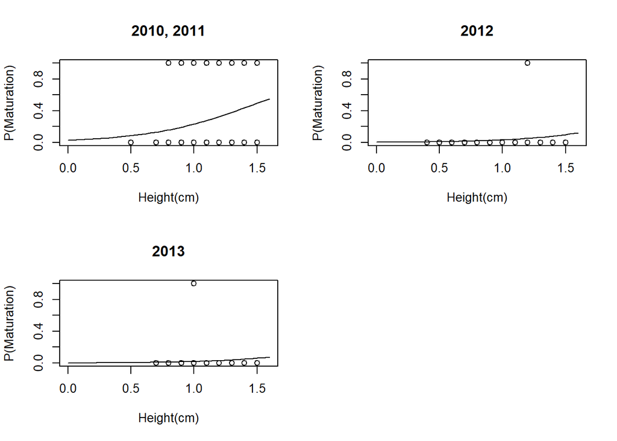

```r
par(mfrow=c(2,2))
plot(x1seq_seedlings, invlogit(m8$coeff[1] + m8$coeff[2]*x2seq_seedlings ), type='l', ylim=c(0,1) , xlab = "Height(cm)", ylab="P(Maturation)", main = "2010, 2011")
points(seedlings2[seedlings2$Year=="2010" | seedlings2$Year == "2011", ]$Diameter_t, seedlings2[seedlings2$Year=="2010" | seedlings2$Year == "2011", ]$grad_status)

plot(x1seq_seedlings, invlogit(m8$coeff[1] + m8$coeff[2]*x2seq_seedlings + m8$coeff[4] ), type='l', ylim=c(0,1) , xlab = "Height(cm)", ylab="P(Maturation)", main = "2012")
points(seedlings2[seedlings2$Year=="2012", ]$Diameter_t, seedlings2[seedlings2$Year=="2012", ]$grad_status)

plot(x1seq_seedlings, invlogit(m8$coeff[1] + m8$coeff[2]*x2seq_seedlings +m8$coeff[5] ), type='l', ylim=c(0,1) , xlab = "Height(cm)", ylab="P(Maturation)", main = "2013")
points(seedlings2[seedlings2$Year=="2013", ]$Diameter_t, seedlings2[seedlings2$Year=="2013", ]$grad_status)
```

### - Diameter + Height models ### –m9: logit(m) = b0 + b1(diameter) + b2(height)

```r
  m9 <- glm(seedlings$grad_status ~ seedlings$Diameter_t + seedlings$Height_t, family =
                binomial)
  summary(m9)
```

```
##
## Call:
## glm(formula = seedlings$grad_status ~ seedlings$Diameter_t +
##     seedlings$Height_t, family = binomial)
##
## Deviance Residuals:
##     Min       1Q   Median       3Q      Max
## -1.1605  -0.4901  -0.3265  -0.2155   2.5576
##
## Coefficients:
##                      Estimate Std. Error z value Pr(>|z|)
## (Intercept)          -7.38857    1.05837  -6.981 2.93e-12 ***
## seedlings$Diameter_t  2.82032    0.78699   3.584 0.000339 ***
## seedlings$Height_t    0.22273    0.07053   3.158 0.001589 **
## ---
## Signif. codes:  0 '***' 0.001 '**' 0.01 '*' 0.05 '.' 0.1 ' ' 1
##
## (Dispersion parameter for binomial family taken to be 1)
##
##     Null deviance: 236.89  on 352  degrees of freedom
## Residual deviance: 201.79  on 350  degrees of freedom
##   (606 observations deleted due to missingness)
## AIC: 207.79
##
## Number of Fisher Scoring iterations: 6
```

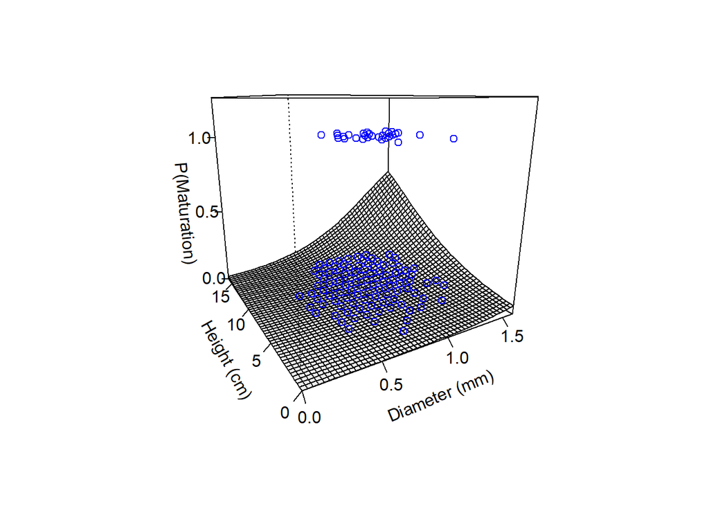

```r
 b0<- m9$coeff[1]
 b1<- m9$coeff[2]
 b2<- m9$coeff[3]


z1<-outer(x1seq_seedlings, x2seq_seedlings, function(a,b) (invlogit(b0 + b1*a + b2*b)))

pmat<-persp(x1seq_seedlings, x2seq_seedlings, z1, ticktype="detailed",
      theta=-30, zlim=c(0, 1.25), zlab="\n P(Maturation)",
      shade=0.1, nticks=4, xlab="\n Diameter (mm)",
      ylab="\n Height (cm)",  lwd=1, xaxs="i",
      main="", cex.main=1)

# from 3D to 2D coordinates
mypoints <- trans3d(seedlings$Diameter_t, seedlings$Height_t, seedlings$grad_status, pmat=pmat)
# plot in 2D space with pointsize related to distance
points(mypoints, col=4)
```

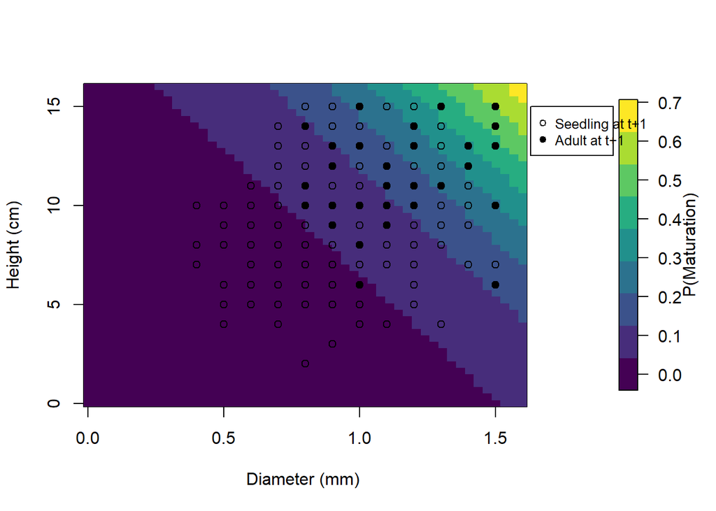

```r
par(mar=c(5.1,4.1,4.1,6))
image.plot(x1seq_seedlings, x2seq_seedlings, z1, xlab = "Diameter (mm) ", ylab="Height (cm)", col=my.palette, legend.lab = "P(Maturation)")
points(seedlings$Diameter_t[seedlings$grad_status==1], seedlings$Height_t[seedlings$grad_status==1], pch=19)
points(seedlings$Diameter_t[seedlings$grad_status==0], seedlings$Height_t[seedlings$grad_status==0], pch=1)
legend(1.63, 15, pch=c(1,19), cex = 0.8, text.width=0.19, c("Seedling at t+1", "Adult at t+1"), xpd=T)
```

### –m10: logit(m) = b0 + b1(diameter) + b2(height) + epsilon(biotype{E,H,W}) Eastern and Hybrid are not different

```r
 m10 <- glm(seedlings$grad_status~ seedlings$Diameter_t + seedlings$Height_t +seedlings$Genetic_type,         family=binomial)
summary(m10)
```

```
##
## Call:
## glm(formula = seedlings$grad_status ~ seedlings$Diameter_t +
##     seedlings$Height_t + seedlings$Genetic_type, family = binomial)
##
## Deviance Residuals:
##     Min       1Q   Median       3Q      Max
## -1.4511  -0.4811  -0.3028  -0.1778   2.6840
##
## Coefficients:
##                               Estimate Std. Error z value Pr(>|z|)
## (Intercept)                   -7.92361    1.14017  -6.949 3.67e-12 ***
## seedlings$Diameter_t           2.56638    0.81085   3.165  0.00155 **
## seedlings$Height_t             0.22287    0.07249   3.074  0.00211 **
## seedlings$Genetic_typehybrid   0.87288    0.50261   1.737  0.08244 .
## seedlings$Genetic_typewestern  1.80039    0.58216   3.093  0.00198 **
## ---
## Signif. codes:  0 '***' 0.001 '**' 0.01 '*' 0.05 '.' 0.1 ' ' 1
##
## (Dispersion parameter for binomial family taken to be 1)
##
##     Null deviance: 236.89  on 352  degrees of freedom
## Residual deviance: 191.75  on 348  degrees of freedom
##   (606 observations deleted due to missingness)
## AIC: 201.75
##
## Number of Fisher Scoring iterations: 6
```

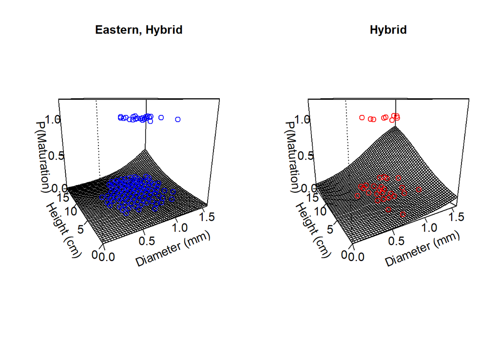

```r
par(mfrow=c(1,2))

#E
b0 <- m10$coeff[1]
b1 <- m10$coeff[2]
b2 <- m10$coeff[3]
z1<-outer(x1seq_seedlings, x2seq_seedlings, function(a,b) (invlogit(b0 + b1*a + b2*b)))

pmat<-persp(x1seq_seedlings, x2seq_seedlings, z1, ticktype="detailed",
      theta=-30, zlim=c(0, 1.25), zlab="\n P(Maturation)",
      shade=0.1, nticks=4, xlab="\n Diameter (mm)",
      ylab="\n Height (cm)",  lwd=1, xaxs="i",
      main="Eastern, Hybrid", cex.main=1)

# from 3D to 2D coordinates
mypoints <- trans3d(seedlings$Diameter_t[seedlings$Genetic_type=="eastern" | seedlings$Genetic_type == "hybrid"], seedlings$Height_t[seedlings$Genetic_type=="eastern" | seedlings$Genetic_type == "hybrid"], seedlings$grad_status[seedlings$Genetic_type=="eastern" | seedlings$Genetic_type == "hybrid"], pmat=pmat)
# plot in 2D space with pointsize related to distance
points(mypoints, col=4)
#H
b0 <- m10$coeff[1] + m10$coeff[5]
b1 <- m10$coeff[2]
b2 <- m10$coeff[3]


z1<-outer(x1seq_seedlings, x2seq_seedlings, function(a,b) (invlogit(b0 + b1*a + b2*b)))

pmat<-persp(x1seq_seedlings, x2seq_seedlings, z1, ticktype="detailed",
      theta=-30, zlim=c(0, 1.25), zlab="\n P(Maturation)",
      shade=0.1, nticks=4, xlab="\n Diameter (mm)",
      ylab="\n Height (cm)",  lwd=1, xaxs="i",
      main="Hybrid", cex.main=1)

# from 3D to 2D coordinates
mypoints <- trans3d(seedlings$Diameter_t[seedlings$Genetic_type=="western"], seedlings$Height_t[seedlings$Genetic_type=="western"], seedlings$grad_status[seedlings$Genetic_type=="western"], pmat=pmat)
# plot in 2D space with pointsize related to distance
points(mypoints, col="red")
```

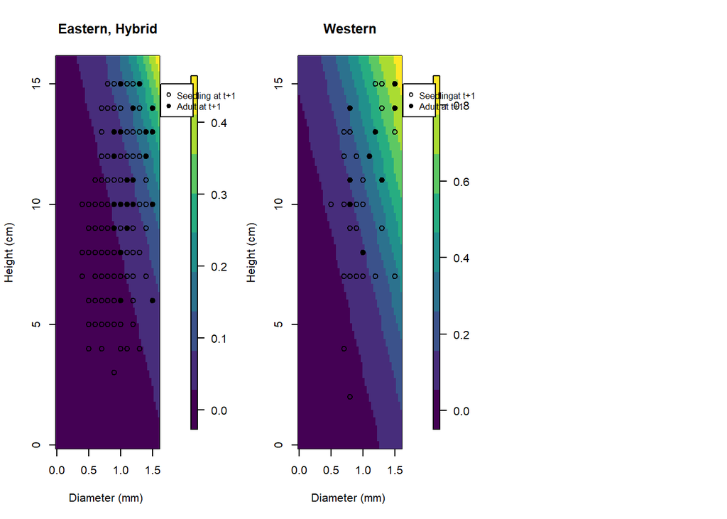

```r
par(mfrow=c(1,2))
#EASTERN/HYBRID
b0 <- m10$coeff[1]
b1 <- m10$coeff[2]
b2 <- m10$coeff[3]

z1<-outer(x1seq_seedlings, x2seq_seedlings, function(a,b) (invlogit(b0 + b1*a + b2*b)))
par(mfrow=c(1,3))
par(mar=c(5.1,4.1,4.1,6))
image.plot(x1seq_seedlings, x2seq_seedlings, z1, xlab = "Diameter (mm) ", ylab="Height (cm)", main="Eastern, Hybrid",col=my.palette)
points(seedlings$Diameter_t[seedlings$grad_status==1 & (seedlings$Genetic_type=="eastern" | seedlings$Genetic_type == "hybrid")], seedlings$Height_t[seedlings$grad_status==1& (seedlings$Genetic_type=="eastern" | seedlings$Genetic_type == "hybrid")], pch=19)
points(seedlings$Diameter_t[seedlings$grad_status==0 & (seedlings$Genetic_type=="eastern" | seedlings$Genetic_type == "hybrid")], seedlings$Height_t[seedlings$grad_status==0&(seedlings$Genetic_type=="eastern" | seedlings$Genetic_type == "hybrid")], pch=1)
legend(1.63, 15, pch=c(1,19), cex = 0.8, text.width=0.19, c("Seedling at t+1", "Adult at t+1"), xpd=T)


#Western
b0 <- m10$coeff[1] + m10$coeff[5]
b1 <- m10$coeff[2]
b2 <- m10$coeff[3]
z1<-outer(x1seq_seedlings, x2seq_seedlings, function(a,b) (invlogit(b0 + b1*a + b2*b)))
image.plot(x1seq_seedlings, x2seq_seedlings, z1, xlab = "Diameter (mm) ", ylab="Height (cm)", main="Western", col=my.palette)
points(seedlings$Diameter_t[seedlings$grad_status==1 & seedlings$Genetic_type=="western"], seedlings$Height_t[seedlings$grad_status==1& seedlings$Genetic_type=="western"], pch=19)
points(seedlings$Diameter_t[seedlings$grad_status==0 & seedlings$Genetic_type=="western"], seedlings$Height_t[seedlings$grad_status==0&seedlings$Genetic_type=="western"], pch=1)
legend(1.63, 15, pch=c(1,19), cex = 0.8, text.width=0.19, c("Seedlingat t+1", "Adult at t+1"), xpd=T)
```

### –m11: logit(m) = b0 + b1(diameter) + b2(height) + epsilon(site{BC, CC, C, FP, PG,WT})

Big Cypress, Cape Canaveral, Fort Pierce and Punta Gorda are not different

```r
m11 <- glm(seedlings$grad_status ~ seedlings$Diameter_t + seedlings$Height_t +
              seedlings$Site, family = binomial)
summary(m11)
```

```
##
## Call:
## glm(formula = seedlings$grad_status ~ seedlings$Diameter_t +
##     seedlings$Height_t + seedlings$Site, family = binomial)
##
## Deviance Residuals:
##     Min       1Q   Median       3Q      Max
## -1.7029  -0.4196  -0.2552  -0.1043   2.6530
##
## Coefficients:
##                              Estimate Std. Error z value Pr(>|z|)
## (Intercept)                  -7.68710    1.24403  -6.179 6.44e-10 ***
## seedlings$Diameter_t          3.55320    0.92179   3.855 0.000116 ***
## seedlings$Height_t            0.20456    0.08145   2.511 0.012028 *
## seedlings$SiteCape Canaveral -0.58247    0.54835  -1.062 0.288135
## seedlings$SiteChekika        -2.76858    1.07545  -2.574 0.010043 *
## seedlings$SiteFort Pierce     0.56420    0.64306   0.877 0.380285
## seedlings$SitePunta Gorda    -0.40671    0.82854  -0.491 0.623517
## seedlings$SiteWild Turkey     1.38661    0.61997   2.237 0.025314 *
## ---
## Signif. codes:  0 '***' 0.001 '**' 0.01 '*' 0.05 '.' 0.1 ' ' 1
##
## (Dispersion parameter for binomial family taken to be 1)
##
##     Null deviance: 236.89  on 352  degrees of freedom
## Residual deviance: 175.13  on 345  degrees of freedom
##   (606 observations deleted due to missingness)
## AIC: 191.13
##
## Number of Fisher Scoring iterations: 7
```

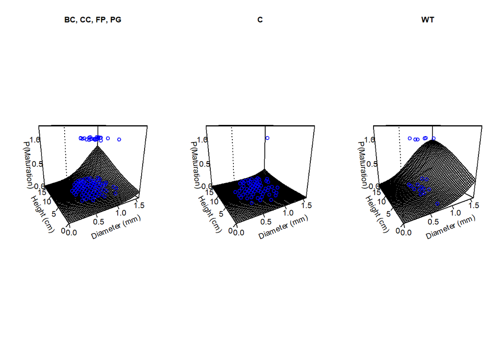

```r
par(mfrow=c(1,3))
  #Big Cypress, Cape Canaveral, Fort Pierce and Punta Gorda
b0 <- m11$coeff[1]
b1 <- m11$coeff[2]
b2 <- m11$coeff[3]
z1<-outer(x1seq_seedlings, x2seq_seedlings, function(a,b) (invlogit(b0 + b1*a + b2*b)))

pmat<-persp(x1seq_seedlings, x2seq_seedlings, z1, ticktype="detailed",
      theta=-30, zlim=c(0, 1.25), zlab="\n P(Maturation)",
      shade=0.1, nticks=4, xlab="\n Diameter (mm)",
      ylab="\n Height (cm)",  lwd=1, xaxs="i",
      main="BC, CC, FP, PG", cex.main=1)

# from 3D to 2D coordinates
mypoints <- trans3d(seedlings$Diameter_t[seedlings$Site=="Big Cypress" | seedlings$Site == "Cape Canaveral" | seedlings$Site == "Fort Pierce" | seedlings$Site == "Punta Gorda"], seedlings$Height_t[seedlings$Site=="Big Cypress" | seedlings$Site == "Cape Canaveral" | seedlings$Site == "Fort Pierce" | seedlings$Site == "Punta Gorda"], seedlings$grad_status[seedlings$Site=="Big Cypress" | seedlings$Site == "Cape Canaveral" | seedlings$Site == "Fort Pierce" | seedlings$Site == "Punta Gorda"], pmat=pmat)
# plot in 2D space with pointsize related to distance
points(mypoints, col=4)

#Chekika
b0 <- m11$coeff[1] + m11$coeff[5]
b1 <- m11$coeff[2]
b2 <- m11$coeff[3]
z1<-outer(x1seq_seedlings, x2seq_seedlings, function(a,b) (invlogit(b0 + b1*a + b2*b)))

pmat<-persp(x1seq_seedlings, x2seq_seedlings, z1, ticktype="detailed",
      theta=-30, zlim=c(0, 1.25), zlab="\n P(Maturation)",
      shade=0.1, nticks=4, xlab="\n Diameter (mm)",
      ylab="\n Height (cm)",  lwd=1, xaxs="i",
      main="C", cex.main=1)

# from 3D to 2D coordinates
mypoints <- trans3d(seedlings$Diameter_t[seedlings$Site=="Chekika"], seedlings$Height_t[seedlings$Site=="Chekika"], seedlings$grad_status[seedlings$Site=="Chekika"], pmat=pmat)
# plot in 2D space with pointsize related to distance
points(mypoints, col=4)


#Wild Turkey
b0 <- m11$coeff[1] + m11$coeff[8]
b1 <- m11$coeff[2]
b2 <- m11$coeff[3]
z1<-outer(x1seq_seedlings, x2seq_seedlings, function(a,b) (invlogit(b0 + b1*a + b2*b)))

pmat<-persp(x1seq_seedlings, x2seq_seedlings, z1, ticktype="detailed",
      theta=-30, zlim=c(0, 1.25), zlab="\n P(Maturation)",
      shade=0.1, nticks=4, xlab="\n Diameter (mm)",
      ylab="\n Height (cm)",  lwd=1, xaxs="i",
      main="WT", cex.main=1)

# from 3D to 2D coordinates
mypoints <- trans3d(seedlings$Diameter_t[seedlings$Site=="Wild Turkey"], seedlings$Height_t[seedlings$Site=="Wild Turkey"], seedlings$grad_status[seedlings$Site=="Wild Turkey"], pmat=pmat)
# plot in 2D space with pointsize related to distance
points(mypoints, col=4)
```

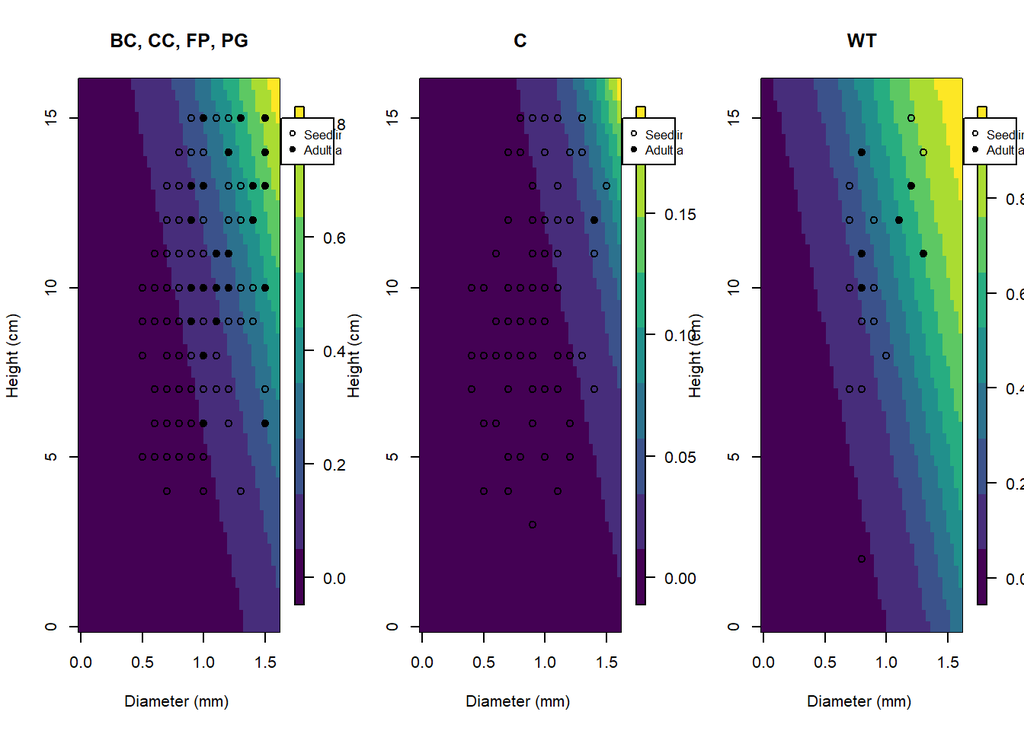

```r
####### Image plots

par(mfrow=c(1,3))
#Big Cypress, Cape Canaveral, Fort Pierce and Punta Gorda
b0 <- m11$coeff[1]
b1 <- m11$coeff[2]
b2 <- m11$coeff[3]
z1<-outer(x1seq_seedlings, x2seq_seedlings, function(a,b) (invlogit(b0 + b1*a + b2*b)))

image.plot(x1seq_seedlings, x2seq_seedlings, z1, xlab = "Diameter (mm) ", ylab="Height (cm)", main="BC, CC, FP, PG", col=my.palette)
points(seedlings$Diameter_t[seedlings$grad_status==1 & (seedlings$Site=="Big Cypress" | seedlings$Site == "Cape Canaveral" | seedlings$Site == "Fort Pierce" | seedlings$Site == "Punta Gorda")], seedlings$Height_t[seedlings$grad_status==1& (seedlings$Site=="Big Cypress" | seedlings$Site == "Cape Canaveral" | seedlings$Site == "Fort Pierce" | seedlings$Site == "Punta Gorda")], pch=19)
points(seedlings$Diameter_t[seedlings$grad_status==0 & (seedlings$Site=="Big Cypress" | seedlings$Site == "Cape Canaveral" | seedlings$Site == "Fort Pierce" | seedlings$Site == "Punta Gorda")], seedlings$Height_t[seedlings$grad_status==0&(seedlings$Site=="Big Cypress" | seedlings$Site == "Cape Canaveral" | seedlings$Site == "Fort Pierce" | seedlings$Site == "Punta Gorda")], pch=1)
legend(1.63, 15, pch=c(1,19), cex = 0.8, text.width=0.19, c("Seedling at t+1", "Adult at t+1"), xpd=T)


#Chekika
b0 <- m11$coeff[1] + m11$coeff[5]
b1 <- m11$coeff[2]
b2 <- m11$coeff[3]
z1<-outer(x1seq_seedlings, x2seq_seedlings, function(a,b) (invlogit(b0 + b1*a + b2*b)))

image.plot(x1seq_seedlings, x2seq_seedlings, z1, xlab = "Diameter (mm) ", ylab="Height (cm)", main="C", col=my.palette)
points(seedlings$Diameter_t[seedlings$grad_status==1 & seedlings$Site=="Chekika"], seedlings$Height_t[seedlings$grad_status==1& seedlings$Site=="Chekika"], pch=19)
points(seedlings$Diameter_t[seedlings$grad_status==0 & seedlings$Site=="Chekika"], seedlings$Height_t[seedlings$grad_status==0&seedlings$Site=="Chekika"], pch=1)
legend(1.63, 15, pch=c(1,19), cex = 0.8, text.width=0.19, c("Seedling at t+1", "Adult at t+1"), xpd=T)

#Wild Turkey
b0 <- m11$coeff[1] + m11$coeff[8]
b1 <- m11$coeff[2]
b2 <- m11$coeff[3]
z1<-outer(x1seq_seedlings, x2seq_seedlings, function(a,b) (invlogit(b0 + b1*a + b2*b)))

image.plot(x1seq_seedlings, x2seq_seedlings, z1, xlab = "Diameter (mm) ", ylab="Height (cm)", main="WT", col=my.palette)
points(seedlings$Diameter_t[seedlings$grad_status==1 & seedlings$Site=="Wild Turkey"], seedlings$Height_t[seedlings$grad_status==1& seedlings$Site=="Wild Turkey"], pch=19)
points(seedlings$Diameter_t[seedlings$grad_status==0 & seedlings$Site=="Wild Turkey"], seedlings$Height_t[seedlings$grad_status==0&seedlings$Site=="Wild Turkey"], pch=1)
legend(1.63, 15, pch=c(1,19), cex = 0.8, text.width=0.19, c("Seedling at t+1", "Adult at t+1"), xpd=T)
```

### –m12: logit(m) = b0 + b1(diameter) + b2(height) + epsilon(year{2010, 2011, 2012, 2013, 2014}) 2010 and 2011 are not different

```r
m12 <- glm(seedlings2$grad_status ~ seedlings2$Diameter_t + seedlings2$Height_t +
              seedlings2$Year, family = binomial)
summary(m12)
```

```
##
## Call:
## glm(formula = seedlings2$grad_status ~ seedlings2$Diameter_t +
##     seedlings2$Height_t + seedlings2$Year, family = binomial)
##
## Deviance Residuals:
##     Min       1Q   Median       3Q      Max
## -1.3550  -0.5196  -0.2465  -0.1458   2.8511
##
## Coefficients:
##                       Estimate Std. Error z value Pr(>|z|)
## (Intercept)           -5.33837    1.20892  -4.416 1.01e-05 ***
## seedlings2$Diameter_t  2.40917    0.98200   2.453  0.01415 *
## seedlings2$Height_t    0.16407    0.08319   1.972  0.04858 *
## seedlings2$Year2011   -1.36227    0.71086  -1.916  0.05532 .
## seedlings2$Year2012   -2.19012    0.77577  -2.823  0.00476 **
## seedlings2$Year2013   -2.75858    1.04728  -2.634  0.00844 **
## ---
## Signif. codes:  0 '***' 0.001 '**' 0.01 '*' 0.05 '.' 0.1 ' ' 1
##
## (Dispersion parameter for binomial family taken to be 1)
##
##     Null deviance: 199.69  on 252  degrees of freedom
## Residual deviance: 151.40  on 247  degrees of freedom
##   (517 observations deleted due to missingness)
## AIC: 163.4
##
## Number of Fisher Scoring iterations: 6
```

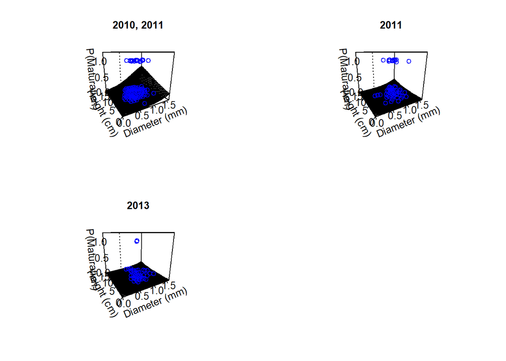

```r
par(mfrow=c(2,2))
#2010
b0 <- m12$coeff[1]
b1 <- m12$coeff[2]
b2 <- m12$coeff[3]
z1<-outer(x1seq_seedlings, x2seq_seedlings, function(a,b) (invlogit(b0 + b1*a + b2*b)))

pmat<-persp(x1seq_seedlings, x2seq_seedlings, z1, ticktype="detailed",
      theta=-30, zlim=c(0, 1.25), zlab="\n P(Maturation)",
      shade=0.1, nticks=4, xlab="\n Diameter (mm)",
      ylab="\n Height (cm)",  lwd=1, xaxs="i",
      main="2010, 2011", cex.main=1)

# from 3D to 2D coordinates
mypoints <- trans3d(seedlings$Diameter_t[seedlings2$Year=="2010" |seedlings2$Year=="2011"], seedlings$Height_t[seedlings2$Year =="2010" | seedlings2$Year == "2011"], seedlings$grad_status[seedlings2$Year=="2010" | seedlings2$Year == "2011"], pmat=pmat)
# plot in 2D space with pointsize related to distance
points(mypoints, col=4)

#2012
b0 <- m12$coeff[1] + m12$coeff[5]
b1 <- m12$coeff[2]
b2 <- m12$coeff[3]
z1<-outer(x1seq_seedlings, x2seq_seedlings, function(a,b) (invlogit(b0 + b1*a + b2*b)))

pmat<-persp(x1seq_seedlings, x2seq_seedlings, z1, ticktype="detailed",
      theta=-30, zlim=c(0, 1.25), zlab="\n P(Maturation)",
      shade=0.1, nticks=4, xlab="\n Diameter (mm)",
      ylab="\n Height (cm)",  lwd=1, xaxs="i",
      main="2011", cex.main=1)

# from 3D to 2D coordinates
mypoints <- trans3d(seedlings$Diameter_t[seedlings2$Year=="2012"], seedlings$Height_t[seedlings2$Year =="2012"], seedlings$grad_status[seedlings2$Year=="2012"], pmat=pmat)
# plot in 2D space with pointsize related to distance
points(mypoints, col=4)

#2013
b0 <- m12$coeff[1] + m12$coeff[6]
b1 <- m12$coeff[2]
b2 <- m12$coeff[3]
z1<-outer(x1seq_seedlings, x2seq_seedlings, function(a,b) (invlogit(b0 + b1*a + b2*b)))

pmat<-persp(x1seq_seedlings, x2seq_seedlings, z1, ticktype="detailed",
      theta=-30, zlim=c(0, 1.25), zlab="\n P(Maturation)",
      shade=0.1, nticks=4, xlab="\n Diameter (mm)",
      ylab="\n Height (cm)",  lwd=1, xaxs="i",
      main="2013", cex.main=1)

# from 3D to 2D coordinates
mypoints <- trans3d(seedlings$Diameter_t[seedlings2$Year=="2013"], seedlings$Height_t[seedlings2$Year =="2013"], seedlings$grad_status[seedlings2$Year=="2013"], pmat=pmat)
# plot in 2D space with pointsize related to distance
points(mypoints, col=4)

####### Image Plots
par(mfrow=c(2,2))
```

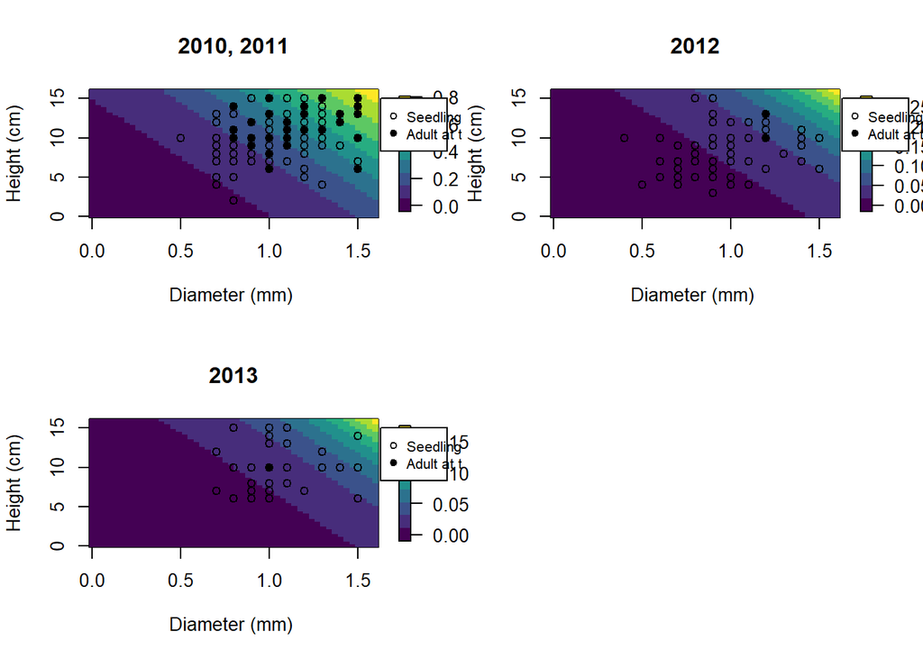

```r
#2010, 2011
b0 <- m12$coeff[1]
b1 <- m12$coeff[2]
b2 <- m12$coeff[3]
z1<-outer(x1seq_seedlings, x2seq_seedlings, function(a,b) (invlogit(b0 + b1*a + b2*b)))

image.plot(x1seq_seedlings, x2seq_seedlings, z1, xlab = "Diameter (mm) ", ylab="Height (cm)", main="2010, 2011", col=my.palette)
points(seedlings2$Diameter_t[seedlings2$grad_status==1 & (seedlings2$Year=="2010" | seedlings2$Year == "2011")], seedlings2$Height_t[seedlings2$grad_status==1& (seedlings2$Year=="2010" | seedlings2$Year == "2011")], pch=19)
points(seedlings2$Diameter_t[seedlings2$grad_status==0 & (seedlings2$Year=="2010" | seedlings2$Year == "2011")], seedlings2$Height_t[seedlings2$grad_status==0&(seedlings2$Year=="2010" | seedlings2$Year == "2011")], pch=1)
legend(1.63, 15, pch=c(1,19), cex = 0.8, text.width=0.19, c("Seedling at t+1", "Adult at t+1"), xpd=T)



#2012
b0 <- m12$coeff[1] +m12$coeff[5]
b1 <- m12$coeff[2]
b2 <- m12$coeff[3]
z1<-outer(x1seq_seedlings, x2seq_seedlings, function(a,b) (invlogit(b0 + b1*a + b2*b)))

image.plot(x1seq_seedlings, x2seq_seedlings, z1, xlab = "Diameter (mm) ", ylab="Height (cm)", main="2012", col=my.palette)
points(seedlings2$Diameter_t[seedlings2$grad_status==1 & seedlings2$Year=="2012"], seedlings2$Height_t[seedlings2$grad_status==1& seedlings2$Year=="2012"], pch=19)
points(seedlings2$Diameter_t[seedlings2$grad_status==0 & seedlings2$Year=="2012"], seedlings2$Height_t[seedlings2$grad_status==0&seedlings2$Year=="2012"], pch=1)
legend(1.63, 15, pch=c(1,19), cex = 0.8, text.width=0.19, c("Seedling at t+1", "Adult at t+1"), xpd=T)


#2013
b0 <- m12$coeff[1] + m12$coeff[6]
b1 <- m12$coeff[2]
b2 <- m12$coeff[3]
z1<-outer(x1seq_seedlings, x2seq_seedlings, function(a,b) (invlogit(b0 + b1*a + b2*b)))

image.plot(x1seq_seedlings, x2seq_seedlings, z1, xlab = "Diameter (mm) ", ylab="Height (cm)", main="2013", col=my.palette)
points(seedlings2$Diameter_t[seedlings2$grad_status==1 & seedlings2$Year=="2013"], seedlings2$Height_t[seedlings2$grad_status==1& seedlings2$Year=="2013"], pch=19)
points(seedlings2$Diameter_t[seedlings2$grad_status==0 & seedlings2$Year=="2013"], seedlings2$Height_t[seedlings2$grad_status==0&seedlings2$Year=="2013"], pch=1)
legend(1.63, 15, pch=c(1,19), cex = 0.8, text.width=0.19, c("Seedling at t+1", "Adult at t+1"), xpd=T)
```

### - AIC

```r
#For all models except year
aictab(list(m1, m2, m3, m5, m6, m7, m9, m10, m11), modnames= c("m1", "m2", "m3", "m5",
                                                             "m6", "m7", "m9", "m10", "m11"))
```

```
##
## Model selection based on AICc:
##
##     K   AICc Delta_AICc AICcWt Cum.Wt      LL
## m11 8 191.55       0.00   0.91   0.91  -87.57
## m3  7 196.20       4.65   0.09   0.99  -90.94
## m10 5 201.93      10.38   0.01   1.00  -95.88
## m7  7 205.26      13.71   0.00   1.00  -95.47
## m9  3 207.86      16.31   0.00   1.00 -100.89
## m2  4 210.09      18.54   0.00   1.00 -100.99
## m6  4 210.32      18.77   0.00   1.00 -101.10
## m1  2 216.63      25.08   0.00   1.00 -106.30
## m5  2 219.36      27.80   0.00   1.00 -107.66
```

```r
#For comparing among the models with year:
aictab(list(m4, m8, m12), modnames=c("m4", "m8", "m12"))
```

```
##
## Model selection based on AICc:
##
##     K   AICc Delta_AICc AICcWt Cum.Wt     LL
## m12 6 163.74       0.00   0.67   0.67 -75.70
## m4  5 165.69       1.96   0.25   0.92 -77.73
## m8  5 167.92       4.19   0.08   1.00 -78.84
```